# DADA2 - OSD 2014

### README:Neu khong hien thi duoc tieng viet: File/Reopen with Encoding… chon mo voi code UTF-8.

# Hướng dẫn sử dụng DADA2

Link của nhà phát triển package dada2 https://benjjneb.github.io/dada2/tutorial.html

Để xử lý với những dữ liệu sinh học, R-Project là một sự lựa chọn khá tất yếu khi R mang lại một môi trường tính toán thống kê chính xác và linh hoạt. Trong đó Bioconductor là một kho các package của R chuyên để sử lí các số liệu sinh học đặc biệt là dữ liệu trình tự nucleotide. Trong nghiên cứu này package Dada2 và phyloseq được áp dụng: Sau khi cài các package bằng function bioClite(), áp dụng chúng vào R session bằng function library()

### Cài đặt các packages

```r
source("https://bioconductor.org/biocLite.R")
biocLite()
biocLite("dada2")
biocLite('phyloseq')
biocLite("DECIPHER")
biocLite("phangorn")
biocLite("BiocStyle")
biocLite("sequencing")
biocLite("BiocGenerics")
biocLite("msa")
```

### Load các package cấn thiết

```r
library("dada2"); packageVersion("dada2")
library("phyloseq"); packageVersion("phyloseq")
library("ggplot2"); packageVersion("ggplot2")


library("sequencing")
library("BiocGenerics")
library("msa")
```

Dữ liệu được sử dụng trong ví dụ này được cung cấp bởi Jean-Christophe, Pháp. Dữ liệu trên được thu thập từ 2 lần thu mẫu tại các biển (open ocean) và các vùng bờ biển trên thế giới. (link http://ocean-microbiome.embl.de/companion.html) Trong thí nghiệm, sự đa dạng sinh học của các vi khuẩn trong mẫu được đánh giá dựa trên trình tự nucleotide 16S rRNA. Các đoạn rRNA này được đọc trình tự dựa trên công nghệ 2x250 của ilunima. Do vậy các đoạn trình tự thu được sẽ có độ dài khoảng 250 nucleotide.

### Tải dữ liệu và dẫn đường dẫn tới tệp chứa các file dữ liệu. Và kiểm tra thành phần các files:

```r
path <- "/Users/nqhuynh/Documents/rdna"
list.files(path)
```

```
  [1] "1"
  [2] "1_DAT.txt"
  [3] "1_OTU1.txt"
  [4] "1_TAX.txt"
  [5] "2"
  [6] "3"
  [7] "4"
  [8] "Callahan 2016 DADA2.R"
  [9] "DADA2 notebook.Rmd"
 [10] "DADA2 notebook.nb.html"
 [11] "Name_list.txt"
 [12] "OSD100_2014-06_1_16S_alma-alma_R1.fastq.gz"
 [13] "OSD100_2014-06_1_16S_alma-alma_R2.fastq.gz"
 [14] "OSD100_2014-06_2_16S_alma-alma_R1.fastq.gz"
 [15] "OSD100_2014-06_2_16S_alma-alma_R2.fastq.gz"
```

[output cut: 323 more lines]

### Lọc và cắt bỏ các đoạn trình tự có chất lượng thấp

## Chuẩn bị

Đầu tiên, chúng ta cần đọc tên các file fastq và dùng một số hàm thay đổi chuỗi kí tự để tạo 2 danh sách file trình tự F và R. Các file chứa trình tự sẽ có tên dạng Tên_R1.fastq.gz hoặc Tên_R2.fastq.gz trong đó R1 là các file trình tự Forward, R2 là các file trình tự Reverse.2 loại trình tự trên được nhóm vào 2 nhóm khác nhau fnFs và fnRs.

```r
fnFs <- sort(list.files(path, pattern="_R1.fastq.gz", full.names = TRUE))
fnRs <- sort(list.files(path, pattern="_R2.fastq.gz", full.names = TRUE))
```

Đưa tên mẫu về dạng: OSDXXX_.fastq

```r
sample.names <- make.unique(sapply(strsplit(basename(fnFs), "_"), `[`, 1))
sample.names
```

```
  [1] "OSD100"   "OSD100.1" "OSD101"   "OSD102"   "OSD103"   "OSD105"
  [7] "OSD106"   "OSD106.1" "OSD107"   "OSD108"   "OSD109"   "OSD10"
 [13] "OSD110"   "OSD111"   "OSD113"   "OSD114"   "OSD115"   "OSD116"
 [19] "OSD117"   "OSD118"   "OSD11"    "OSD11.1"  "OSD11.2"  "OSD122"
 [25] "OSD123"   "OSD124"   "OSD125"   "OSD126"   "OSD127"   "OSD128"
 [31] "OSD129"   "OSD130"   "OSD131"   "OSD132"   "OSD133"   "OSD13"
 [37] "OSD141"   "OSD142"   "OSD143"   "OSD144"   "OSD145"   "OSD146"
 [43] "OSD147"   "OSD148"   "OSD149"   "OSD14"    "OSD150"   "OSD151"
 [49] "OSD152"   "OSD152.1" "OSD152.2" "OSD153"   "OSD154"   "OSD155"
 [55] "OSD155.1" "OSD156"   "OSD156.1" "OSD157"   "OSD157.1" "OSD158"
 [61] "OSD159"   "OSD15"    "OSD15.1"  "OSD162"   "OSD163"   "OSD164"
 [67] "OSD165"   "OSD166"   "OSD167"   "OSD168"   "OSD169"   "OSD170"
 [73] "OSD171"   "OSD172"   "OSD173"   "OSD174"   "OSD175"   "OSD176"
 [79] "OSD177"   "OSD178"   "OSD17"    "OSD182"   "OSD183"   "OSD184"
 [85] "OSD185"   "OSD186"   "OSD187"   "OSD18"    "OSD19"    "OSD1"
 [91] "OSD20"    "OSD20.1"  "OSD21"    "OSD21.1"  "OSD21.2"  "OSD22"
 [97] "OSD24"    "OSD25"    "OSD26"    "OSD28"    "OSD29"    "OSD2"
[103] "OSD30"    "OSD34"    "OSD35"    "OSD36"    "OSD37"    "OSD38"
[109] "OSD39"    "OSD3"     "OSD41"    "OSD42"    "OSD43"    "OSD45"
[115] "OSD46"    "OSD47"    "OSD48"    "OSD49"    "OSD4"     "OSD50"
[121] "OSD51"    "OSD52"    "OSD53"    "OSD54"    "OSD55"    "OSD56"
[127] "OSD57"    "OSD58"    "OSD5"     "OSD5.1"   "OSD60"    "OSD61"
[133] "OSD62"    "OSD63"    "OSD64"    "OSD65"    "OSD69"    "OSD6"
[139] "OSD70"    "OSD71"    "OSD72"    "OSD73"    "OSD74"    "OSD76"
[145] "OSD77"    "OSD78"    "OSD7"     "OSD80"    "OSD80.1"  "OSD81"
[151] "OSD8"     "OSD90"    "OSD90.1"  "OSD91"    "OSD92"    "OSD93"
[157] "OSD94"    "OSD95"    "OSD96"    "OSD97"    "OSD98"    "OSD99"
```

```r
sample.namesfull <- sapply(strsplit(basename(fnFs), "_16S"), `[`, 1)
```

## Kiểm tra chất lượng trình tự

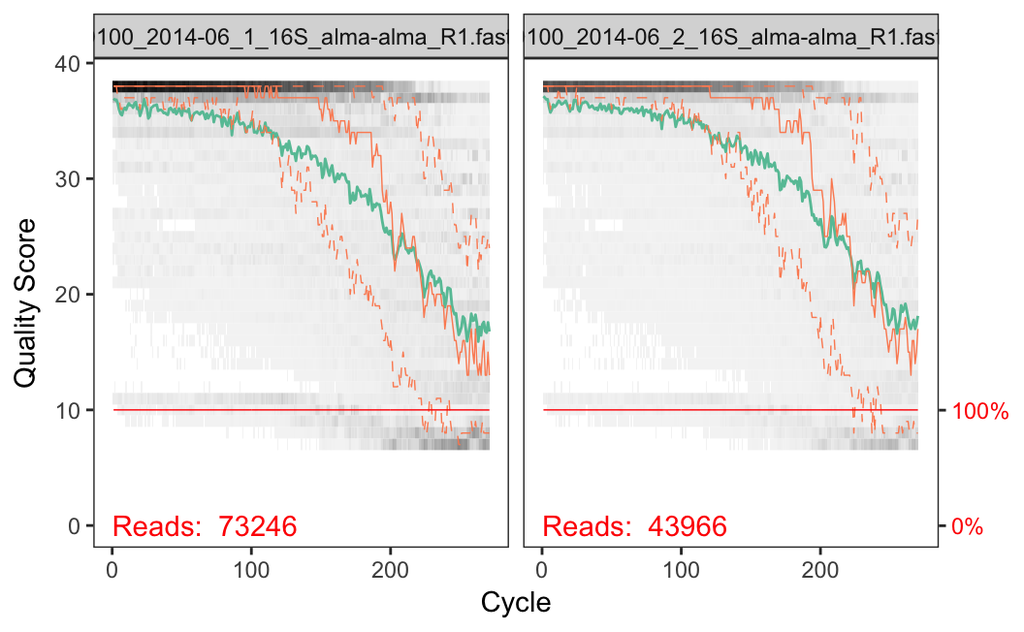

```r
plotQualityProfile(fnFs[1:2])
```

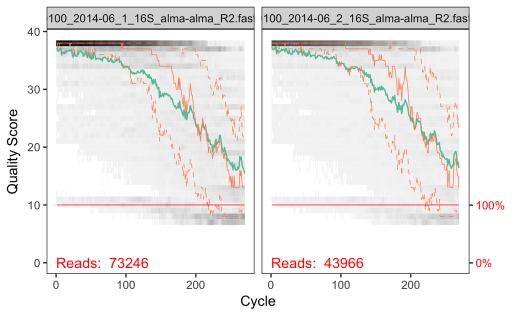

```r
plotQualityProfile(fnRs[1:2])
```

Thang màu xám là bản đồ nhiệt (heat-map) thể hiện chất lượng của trình tự của từng nucleotide. Đường màu xanh biểu diễn điểm chất lượng trung bình của mỗi vị trí nucleotide, và đường màu cam biểu diễn tứ phân vị sự phân bố điểm chất lượng các nucleotide. Đường màu đỏ biểu diễn tỷ lệ số trình tự có độ dài ở vị trí nucleotide đó. Đối với ví dụ này trình tự được đọc trên máy Ilumina các đoạn đọc có độ dài như nhau ~250Nu, vì vậy mà đường màu đỏ ở ví dụ này nằm song song với trục x.

## Cắt và lọc trình tự

Gán tên file cho các trình tự sau khi cắt và lọc các file fastq.gz.

```r
filtFs <- file.path(path, "filtered", paste0(sample.names, "_F_filt.fastq.gz"))
filtRs <- file.path(path, "filtered", paste0(sample.names, "_R_filt.fastq.gz"))
```

Cắt và lọc các trình tự, tuỳ vào chất lượng của trình tự mà các thông số dưới đây có thể được thay đổi, thông thường điểm chất lượng trung bình khoảng >20 là có thể chấp nhận. Thông số truncLen = c(F, R) dùng để cắt bỏ đoạn đuôi trình tự có chất lượng thấp, như thể hiện trên hình chất lượng trình tự, đoạn cuối hay đuôi của trình tự thường có chất lượng kém, nên tuy đoạn trình tự có độ dài là 250Nu, nhưng chỉ 220Nu được dùng cho các bước tiếp theo. Thông số maxEE = c(F, R) dùng để khai báo sai số cho phép đi qua bước lọc. Thông số này càng nhỏ (2) thì sai số cho phép đi qua bước lọc càng nhỏ và ngược lại, thông số maxEE càng lớn (5) sai đó cho phép đi qua bước lọc càng cao. Điều này có nghĩa là khi maxEE = c(2,2) sai số của trình tự được phép đi qua bước lọc nhỏ và những trình tự có sai số lớn sẽ không thể đi qua, ngược lại khi maxEE được nới lỏng c(5,5) hầu hết các trình tự đều có thể đi qua kể cả các trình tự có sai số lớn.

```r
out <- filterAndTrim(fnFs, filtFs, fnRs, filtRs, truncLen=c(220, 220),
                     maxN=0, truncQ=2, maxEE = c(2,2), rm.phix=TRUE,
                     compress=TRUE, multithread=TRUE)
```

Kiển tra out, reads.in là số trình tự trước khi lọc, và reads.out là số trình tự sau khi lọc

```r
head(out)
```

```
                                           reads.in reads.out
OSD100_2014-06_1_16S_alma-alma_R1.fastq.gz    73246     14488
OSD100_2014-06_2_16S_alma-alma_R1.fastq.gz    43966     11829
OSD101_2014-06_1_16S_alma-alma_R1.fastq.gz    94207     24940
OSD102_2014-06_1_16S_alma-alma_R1.fastq.gz    86605     21822
OSD103_2014-06_1_16S_alma-alma_R1.fastq.gz    79608     15964
OSD105_2014-06_1_16S_alma-alma_R1.fastq.gz    85031     21022
```

### Tỷ lệ sai của các trình tự

```r
errF <- learnErrors(filtFs, multithread=TRUE)
```

```
101199780 total bases in 459999 reads from 29 samples will be used for learning the error rates.
Initializing error rates to maximum possible estimate.
selfConsist step 1 .............................
   selfConsist step 2
   selfConsist step 3
   selfConsist step 4
   selfConsist step 5
Convergence after  5  rounds.
```

```r
errR <- learnErrors(filtRs, multithread=TRUE)
```

```
101199780 total bases in 459999 reads from 29 samples will be used for learning the error rates.
Initializing error rates to maximum possible estimate.
selfConsist step 1 .............................
   selfConsist step 2
   selfConsist step 3
   selfConsist step 4
   selfConsist step 5
Convergence after  5  rounds.
```

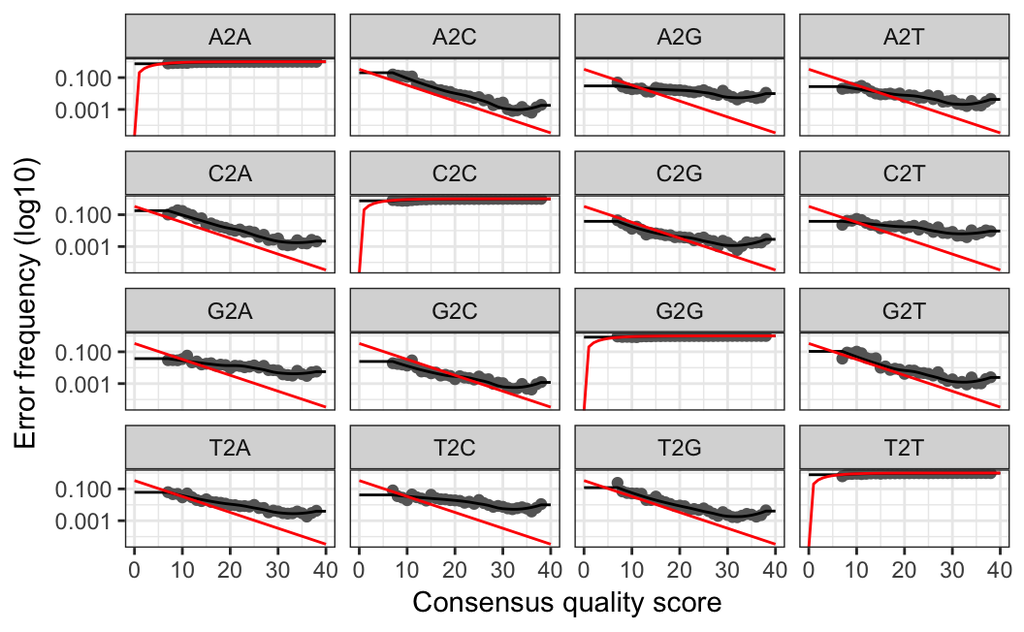

```r
plotErrors(errF, nominalQ=TRUE)
```

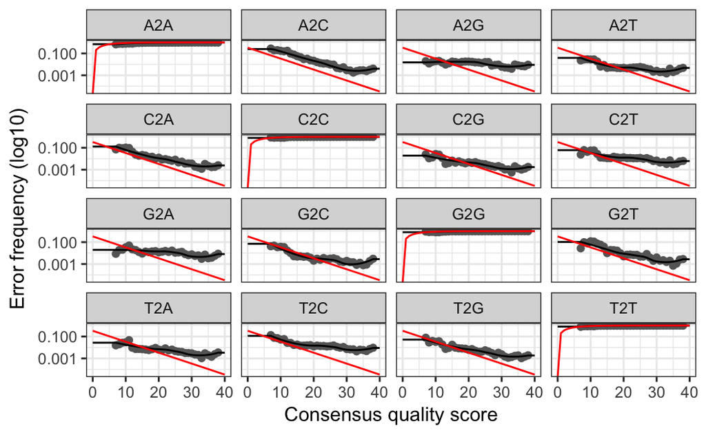

```r
plotErrors(errR, nominalQ=TRUE)
```

### Dereplication

Dereplicate the filtered fastq files

```r
derepFs <- derepFastq(filtFs, verbose=TRUE)
```

```
Dereplicating sequence entries in Fastq file: /Users/nqhuynh/Documents/rdna/filtered/OSD100_F_filt.fastq.gz
Encountered 8111 unique sequences from 14488 total sequences read.
Dereplicating sequence entries in Fastq file: /Users/nqhuynh/Documents/rdna/filtered/OSD100.1_F_filt.fastq.gz
Encountered 6820 unique sequences from 11829 total sequences read.
Dereplicating sequence entries in Fastq file: /Users/nqhuynh/Documents/rdna/filtered/OSD101_F_filt.fastq.gz
Encountered 12890 unique sequences from 24940 total sequences read.
Dereplicating sequence entries in Fastq file: /Users/nqhuynh/Documents/rdna/filtered/OSD102_F_filt.fastq.gz
Encountered 12066 unique sequences from 21822 total sequences read.
Dereplicating sequence entries in Fastq file: /Users/nqhuynh/Documents/rdna/filtered/OSD103_F_filt.fastq.gz
Encountered 9962 unique sequences from 15964 total sequences read.
Dereplicating sequence entries in Fastq file: /Users/nqhuynh/Documents/rdna/filtered/OSD105_F_filt.fastq.gz
Encountered 12305 unique sequences from 21022 total sequences read.
Dereplicating sequence entries in Fastq file: /Users/nqhuynh/Documents/rdna/filtered/OSD106_F_filt.fastq.gz
Encountered 8146 unique sequences from 14510 total sequences read.
Dereplicating sequence entries in Fastq file: /Users/nqhuynh/Documents/rdna/filtered/OSD106.1_F_filt.fastq.gz
Encountered 11721 unique sequences from 21575 total sequences read.
Dereplicating sequence entries in Fastq file: /Users/nqhuynh/Documents/rdna/filtered/OSD107_F_filt.fastq.gz
Encountered 9849 unique sequences from 15555 total sequences read.
Dereplicating sequence entries in Fastq file: /Users/nqhuynh/Documents/rdna/filtered/OSD108_F_filt.fastq.gz
Encountered 15286 unique sequences from 26342 total sequences read.
Dereplicating sequence entries in Fastq file: /Users/nqhuynh/Documents/rdna/filtered/OSD109_F_filt.fastq.gz
Encountered 12628 unique sequences from 19472 total sequences read.
Dereplicating sequence entries in Fastq file: /Users/nqhuynh/Documents/rdna/filtered/OSD10_F_filt.fastq.gz
Encountered 9819 unique sequences from 17569 total sequences read.
Dereplicating sequence entries in Fastq file: /Users/nqhuynh/Documents/rdna/filtered/OSD110_F_filt.fastq.gz
Encountered 12181 unique sequences from 17521 total sequences read.
Dereplicating sequence entries in Fastq file: /Users/nqhuynh/Documents/rdna/filtered/OSD111_F_filt.fastq.gz
Encountered 4844 unique sequences from 9326 total sequences read.
Dereplicating sequence entries in Fastq file: /Users/nqhuynh/Documents/rdna/filtered/OSD113_F_filt.fastq.gz
Encountered 8979 unique sequences from 16389 total sequences read.
Dereplicating sequence entries in Fastq file: /Users/nqhuynh/Documents/rdna/filtered/OSD114_F_filt.fastq.gz
Encountered 258 unique sequences from 370 total sequences read.
Dereplicating sequence entries in Fastq file: /Users/nqhuynh/Documents/rdna/filtered/OSD115_F_filt.fastq.gz
Encountered 8209 unique sequences from 16550 total sequences read.
Dereplicating sequence entries in Fastq file: /Users/nqhuynh/Documents/rdna/filtered/OSD116_F_filt.fastq.gz
Encountered 1534 unique sequences from 2587 total sequences read.
Dereplicating sequence entries in Fastq file: /Users/nqhuynh/Documents/rdna/filtered/OSD117_F_filt.fastq.gz
Encountered 8620 unique sequences from 14889 total sequences read.
Dereplicating sequence entries in Fastq file: /Users/nqhuynh/Documents/rdna/filtered/OSD118_F_filt.fastq.gz
Encountered 11286 unique sequences from 20405 total sequences read.
```

[output cut: 269 more lines]

```
Encountered 9902 unique sequences from 16196 total sequences read.
Dereplicating sequence entries in Fastq file: /Users/nqhuynh/Documents/rdna/filtered/OSD93_F_filt.fastq.gz
Encountered 6937 unique sequences from 10573 total sequences read.
Dereplicating sequence entries in Fastq file: /Users/nqhuynh/Documents/rdna/filtered/OSD94_F_filt.fastq.gz
Encountered 9268 unique sequences from 14188 total sequences read.
Dereplicating sequence entries in Fastq file: /Users/nqhuynh/Documents/rdna/filtered/OSD95_F_filt.fastq.gz
Encountered 9754 unique sequences from 16450 total sequences read.
Dereplicating sequence entries in Fastq file: /Users/nqhuynh/Documents/rdna/filtered/OSD96_F_filt.fastq.gz
Encountered 5247 unique sequences from 13543 total sequences read.
Dereplicating sequence entries in Fastq file: /Users/nqhuynh/Documents/rdna/filtered/OSD97_F_filt.fastq.gz
Encountered 10370 unique sequences from 16501 total sequences read.
Dereplicating sequence entries in Fastq file: /Users/nqhuynh/Documents/rdna/filtered/OSD98_F_filt.fastq.gz
Encountered 12258 unique sequences from 19404 total sequences read.
Dereplicating sequence entries in Fastq file: /Users/nqhuynh/Documents/rdna/filtered/OSD99_F_filt.fastq.gz
Encountered 3752 unique sequences from 6589 total sequences read.
```

```r
derepRs <- derepFastq(filtRs, verbose=TRUE)
```

```
Dereplicating sequence entries in Fastq file: /Users/nqhuynh/Documents/rdna/filtered/OSD100_R_filt.fastq.gz
Encountered 7404 unique sequences from 14488 total sequences read.
Dereplicating sequence entries in Fastq file: /Users/nqhuynh/Documents/rdna/filtered/OSD100.1_R_filt.fastq.gz
Encountered 6272 unique sequences from 11829 total sequences read.
Dereplicating sequence entries in Fastq file: /Users/nqhuynh/Documents/rdna/filtered/OSD101_R_filt.fastq.gz
Encountered 12307 unique sequences from 24940 total sequences read.
Dereplicating sequence entries in Fastq file: /Users/nqhuynh/Documents/rdna/filtered/OSD102_R_filt.fastq.gz
Encountered 11390 unique sequences from 21822 total sequences read.
Dereplicating sequence entries in Fastq file: /Users/nqhuynh/Documents/rdna/filtered/OSD103_R_filt.fastq.gz
Encountered 9371 unique sequences from 15964 total sequences read.
Dereplicating sequence entries in Fastq file: /Users/nqhuynh/Documents/rdna/filtered/OSD105_R_filt.fastq.gz
Encountered 12017 unique sequences from 21022 total sequences read.
Dereplicating sequence entries in Fastq file: /Users/nqhuynh/Documents/rdna/filtered/OSD106_R_filt.fastq.gz
Encountered 7681 unique sequences from 14510 total sequences read.
Dereplicating sequence entries in Fastq file: /Users/nqhuynh/Documents/rdna/filtered/OSD106.1_R_filt.fastq.gz
Encountered 11363 unique sequences from 21575 total sequences read.
Dereplicating sequence entries in Fastq file: /Users/nqhuynh/Documents/rdna/filtered/OSD107_R_filt.fastq.gz
Encountered 9385 unique sequences from 15555 total sequences read.
Dereplicating sequence entries in Fastq file: /Users/nqhuynh/Documents/rdna/filtered/OSD108_R_filt.fastq.gz
Encountered 14648 unique sequences from 26342 total sequences read.
Dereplicating sequence entries in Fastq file: /Users/nqhuynh/Documents/rdna/filtered/OSD109_R_filt.fastq.gz
Encountered 12000 unique sequences from 19472 total sequences read.
Dereplicating sequence entries in Fastq file: /Users/nqhuynh/Documents/rdna/filtered/OSD10_R_filt.fastq.gz
Encountered 9528 unique sequences from 17569 total sequences read.
Dereplicating sequence entries in Fastq file: /Users/nqhuynh/Documents/rdna/filtered/OSD110_R_filt.fastq.gz
Encountered 11513 unique sequences from 17521 total sequences read.
Dereplicating sequence entries in Fastq file: /Users/nqhuynh/Documents/rdna/filtered/OSD111_R_filt.fastq.gz
Encountered 4704 unique sequences from 9326 total sequences read.
Dereplicating sequence entries in Fastq file: /Users/nqhuynh/Documents/rdna/filtered/OSD113_R_filt.fastq.gz
Encountered 8945 unique sequences from 16389 total sequences read.
Dereplicating sequence entries in Fastq file: /Users/nqhuynh/Documents/rdna/filtered/OSD114_R_filt.fastq.gz
Encountered 258 unique sequences from 370 total sequences read.
Dereplicating sequence entries in Fastq file: /Users/nqhuynh/Documents/rdna/filtered/OSD115_R_filt.fastq.gz
Encountered 8291 unique sequences from 16550 total sequences read.
Dereplicating sequence entries in Fastq file: /Users/nqhuynh/Documents/rdna/filtered/OSD116_R_filt.fastq.gz
Encountered 1542 unique sequences from 2587 total sequences read.
Dereplicating sequence entries in Fastq file: /Users/nqhuynh/Documents/rdna/filtered/OSD117_R_filt.fastq.gz
Encountered 8452 unique sequences from 14889 total sequences read.
Dereplicating sequence entries in Fastq file: /Users/nqhuynh/Documents/rdna/filtered/OSD118_R_filt.fastq.gz
Encountered 11120 unique sequences from 20405 total sequences read.
```

[output cut: 269 more lines]

```
Encountered 9583 unique sequences from 16196 total sequences read.
Dereplicating sequence entries in Fastq file: /Users/nqhuynh/Documents/rdna/filtered/OSD93_R_filt.fastq.gz
Encountered 6853 unique sequences from 10573 total sequences read.
Dereplicating sequence entries in Fastq file: /Users/nqhuynh/Documents/rdna/filtered/OSD94_R_filt.fastq.gz
Encountered 8977 unique sequences from 14188 total sequences read.
Dereplicating sequence entries in Fastq file: /Users/nqhuynh/Documents/rdna/filtered/OSD95_R_filt.fastq.gz
Encountered 9021 unique sequences from 16450 total sequences read.
Dereplicating sequence entries in Fastq file: /Users/nqhuynh/Documents/rdna/filtered/OSD96_R_filt.fastq.gz
Encountered 7119 unique sequences from 13543 total sequences read.
Dereplicating sequence entries in Fastq file: /Users/nqhuynh/Documents/rdna/filtered/OSD97_R_filt.fastq.gz
Encountered 9963 unique sequences from 16501 total sequences read.
Dereplicating sequence entries in Fastq file: /Users/nqhuynh/Documents/rdna/filtered/OSD98_R_filt.fastq.gz
Encountered 11621 unique sequences from 19404 total sequences read.
Dereplicating sequence entries in Fastq file: /Users/nqhuynh/Documents/rdna/filtered/OSD99_R_filt.fastq.gz
Encountered 3243 unique sequences from 6589 total sequences read.
```

Gán tên mẫu cho derep Forward và reverse

```r
names(derepFs) <- sample.names
names(derepRs) <- sample.names
```

Sample Inference Infer the sequence variants in each sample

```r
dadaFs <- dada(derepFs, err=errF, multithread=TRUE)
dadaRs <- dada(derepRs, err=errR, multithread=TRUE)
```

Kiểm tra class của dada object

```r
dadaFs[[1]]
```

```
dada-class: object describing DADA2 denoising results
102 sequence variants were inferred from 8111 input unique sequences.
Key parameters: OMEGA_A = 1e-40, OMEGA_C = 1e-40, BAND_SIZE = 16
```

```r
dadaRs[[1]]
```

```
dada-class: object describing DADA2 denoising results
108 sequence variants were inferred from 7404 input unique sequences.
Key parameters: OMEGA_A = 1e-40, OMEGA_C = 1e-40, BAND_SIZE = 16
```

### Ghép các trình tự đã được loại bỏ nhiễu

```r
mergers <- mergePairs(dadaFs, derepFs, dadaRs, derepRs, verbose=TRUE)
```

Kiểm tra giá trị của trình tự đầu tiên trong mergers

```r
head(mergers[[1]])
```

```
                                                                                                                                                                                                                                                                                                            …
1     TACGAAGGGACCTAGCGTAGTTCGGAATTACTGGGCTTAAAGAGTTCGTAGGTGGTTGAA…
2     TACGAAGGGACCTAGCGTAGTTCGGAATTACTGGGCTTAAAGAGTTCGTAGGTGGTTGAA…
3 TACGGGAGTGGCAAGCGTTATCCGGAATTATTGGGCGTAAAGCGTCCGCAGGCGGCCCTT…
4       TACGGAAGGTCCTAGCGTTGTTCGGAATTACTGGGCGTAAAGCGCATGTAGGCGGAACAG…
5       TACGGAAGGTCCTAGCGTTGTTCGGAATTACTGGGCGTAAAGCGCATGTAGGCGGAACAA…
6    TACGAAGGGGGCGAGCGTTATTCGGAATTATTGGGCGTAAAGGGCTCGCAGGCTGCTTGA…
  abundance forward reverse nmatch nmismatch nindel prefer accept
1      2161       1       1     70         0      0      2   TRUE
2      1318       2       1     70         0      0      2   TRUE
3       837       3       3     66         0      0      2   TRUE
4       657       4       2     72         0      0      2   TRUE
5       576       5       2     72         0      0      2   TRUE
6       318       8       5     69         0      0      2   TRUE
```

### Xây dựng bảng trình tự

```r
seqtab <- makeSequenceTable(mergers)
```

```
The sequences being tabled vary in length.
```

```r
dim(seqtab)
```

```
[1]   162 11996
```

Kiểm tra sự khác nhau của độ dài các trình tự

```r
table(nchar(getSequences(seqtab)))
```

```
 273  274  311  312  342  357  362  363  364  365  366  367  368  369  370
   2    1    1    1    1    1   14    3   12   29  347   59  749  229 2417
 371  372  373  374  375  376  377  378  379  381  383  384  390  398  412
 697 2238 1404 2681  372  648   75    1    1    2    2    1    2    1    1
 417  425  427
   1    2    1
```

### Loại bỏ Chimera

```r
seqtab.nochim <- removeBimeraDenovo(seqtab, method="consensus", multithread=TRUE, verbose=TRUE)
```

```
Identified 6263 bimeras out of 11996 input sequences.
```

```r
dim(seqtab.nochim)
```

```
[1]  162 5733
```

```r
sum(seqtab.nochim)/sum(seqtab)
```

```
[1] 0.9210133
```

Nếu giá trị = 1, 0% trình tự chimera bị loại bỏ, 0,9=10% trình tự chimera bị loại bỏ…

### Kiểm tra các trình tự đã được sử lí qua pipline dada2

```r
getN <- function(x) sum(getUniques(x))
track <- cbind(out, sapply(dadaFs, getN), sapply(mergers, getN), rowSums(seqtab), rowSums(seqtab.nochim))
colnames(track) <- c("input", "filtered", "denoised", "merged", "tabled", "nonchim")
rownames(track) <- sample.names
head(track)
```

```
         input filtered denoised merged tabled nonchim
OSD100   73246    14488    14215  11976  11976   11511
OSD100.1 43966    11829    11493   9711   9711    9092
OSD101   94207    24940    24146  21220  21220   19080
OSD102   86605    21822    20878  18290  18290   16973
OSD103   79608    15964    15272  12462  12462   11701
OSD105   85031    21022    20547  16428  16428   14203
```

### Gán taxonomy

Tải “silva_nr_v132_train_set.fa” và " silva_species_assignment_v132.fa" từ “https://benjjneb.github.io/dada2/training.html”

```r
taxaRC <- assignTaxonomy(seqtab.nochim, "/Users/nqhuynh/Documents/Trainset/silva_nr_v132_train_set.fa", tryRC=TRUE)
taxaSp <- addSpecies(taxaRC, "/Users/nqhuynh/Documents/Trainset/silva_species_assignment_v132.fa")
```

```r
taxa.print <- taxaSp
rownames(taxa.print) <- NULL
head(taxa.print)
```

```
     Kingdom    Phylum           Class                 Order
[1,] "Bacteria" "Proteobacteria" "Alphaproteobacteria" "SAR11_clade"
[2,] "Bacteria" "Proteobacteria" "Alphaproteobacteria" "SAR11_clade"
[3,] "Bacteria" "Proteobacteria" "Alphaproteobacteria" "SAR11_clade"
[4,] "Bacteria" "Proteobacteria" "Alphaproteobacteria" "SAR11_clade"
[5,] "Bacteria" "Proteobacteria" "Alphaproteobacteria" "SAR11_clade"
[6,] "Bacteria" "Cyanobacteria"  "Oxyphotobacteria"    "Chloroplast"
     Family     Genus      Species
[1,] "Clade_I"  "Clade_Ia" NA
[2,] "Clade_I"  "Clade_Ia" NA
[3,] "Clade_I"  "Clade_Ia" NA
[4,] "Clade_I"  "Clade_Ia" NA
[5,] "Clade_II" NA         NA
[6,] NA         NA         NA
```

### Thông tin về môi trường địa điểm thời gian thu mẫu năm 2014

xem hướng dẫn tại https://github.com/MicroB3-IS/osd-analysis/wiki/OSD-2014-environmental-data-csv-documentation# Import OSD metdata

```
# The data set itself is documented here:
# https://github.com/MicroB3-IS/osd-analysis/wiki/OSD-2014-environmental-data-csv-documentation
# If you spot any errors in this data, plese post an issue to:
# https://github.com/MicroB3-IS/osd-analysis/issues

# First step, pull the data from the database export online.
# Note: if not using Windows, you may need to use RCurl.

setInternet2(TRUE) # Allows https access

# pull CSV file, declare that its first row is a row of headers (col names)
# that it is pipe, "|", separated, and that
# data are quoted with double quotes

# This could be (should be?) switched to PANGAEA's tsv link...
rawContextualData <- read.csv(
    "https://owncloud.mpi-bremen.de/index.php/s/eaB3ChiDG6i9C6M/download?path=%2F2014%2Fsamples&files=OSD2014_environmental_metadata_2015-11-17.csv",
    header = T,
    sep = "|",
    quote = '"',
    colClasses = "character"
    )

# Set row names to a (sensible) unique identifier, here I chose the ENA
# accession code, already in the data.
row.names(rawContextualData) <- rawContextualData[, "label"]

# check the dimensions of the table...
#  dim(rawContextualData)
#    [1] 203  54

# Now, partition the table into objects that contain logically aggregated

# Create a table mapping various IDs to one another...
sampleMap <- rawContextualData[
    ,
    c(
        "osd_id",
        "label",
        "bioarchive_code",
```

[output cut: 135 more lines]

```
# For semantic consistency, replace NaNs with NAs
numericData[is.nan(numericData)] <- NA

combinedEnvSpatTempData <- data.frame(
  spatialData,
  temporalData,
  factorData,
  numericData
  )

#Clean up ...
rm(list = c("tempNames", "i"))
gc()

####Kết thúc OSD 2014 environmental table###########
```

### Sau khi chạy script trong link trên lưu bảng data dưới dạng .txt

```
write.table(combinedEnvSpatTempData, file = "/file directory/data1.txt",header=TRUE, sep="\t", dec=",")
```

Đưa bảng data1 trở lại R session

```r
envdata <- read.table("/Users/nqhuynh/Documents/rdna/3/data1.txt", header=TRUE, fill=TRUE, row.names=1, sep="\t", dec=",")
envdata
```

```
                                start_lat   start_lon   stop_lat
OSD191_2014-07-02_0m_NPL022    -12.338200  130.695200 -12.338200
OSD190_2014-07-13_0m_NPL022    -35.837200  136.441300 -35.837200
OSD189_2014-06-24_0m_NPL022    -19.305000  147.622000 -19.305000
OSD188_2014-06-24_0m_NPL022    -32.000000  115.416700 -32.000000
OSD186_2014-06-21_2.4m_NPL022   38.885507  -76.541600  38.885507
OSD185_2014-06-24_3m_NPL022     51.481583    2.451483  51.481583
OSD184_2014-06-24_3m_NPL022     51.682917    2.415200  51.682717
OSD183_2014-06-24_3m_NPL022     51.748350    2.698000  51.748350
OSD182_2014-06-24_3m_NPL022     51.458433    2.350467  51.458433
OSD178_2014-06-24_3m_NPL022     51.580333    2.789700  51.580317
OSD177_2014-06-24_3m_NPL022     51.185750    2.701667  51.185917
OSD176_2014-06-24_3m_NPL022     51.277700    2.613500  51.277933
OSD175_2014-06-24_3m_NPL022     51.334817    2.502150  51.334817
OSD174_2014-06-25_3m_NPL022     51.471567    3.059167  51.471583
OSD173_2014-06-25_3m_NPL022     51.441017    3.139950  51.441017
OSD172_2014-06-25_3m_NPL022     51.374850    3.218333  51.374850
OSD171_2014-06-25_3m_NPL022     51.307333    2.849333  51.307333
OSD170_2014-06-25_3m_NPL022     51.269517    2.904700  51.269500
OSD169_2014-06-21_0.1m_NPL022   51.796139    1.012958  51.796139
OSD168_2014-06-21_2m_NPL022     38.413330   27.034210  38.413330
OSD167_2014-06-21_0.1m_NPL022   65.706400  -18.118100  65.706400
OSD166_2014-06-21_0.5m_NPL022   43.432870   -2.900560  43.432870
                                  stop_lon water_depth local_date
OSD191_2014-07-02_0m_NPL022     130.695200        0.00 2014-07-02
OSD190_2014-07-13_0m_NPL022     136.441300        0.00 2014-07-13
OSD189_2014-06-24_0m_NPL022     147.622000        0.00 2014-06-24
OSD188_2014-06-24_0m_NPL022     115.416700        0.00 2014-06-24
OSD186_2014-06-21_2.4m_NPL022   -76.541600        2.40 2014-06-21
OSD185_2014-06-24_3m_NPL022       2.451483        3.00 2014-06-24
OSD184_2014-06-24_3m_NPL022       2.414967        3.00 2014-06-24
OSD183_2014-06-24_3m_NPL022       2.698000        3.00 2014-06-24
OSD182_2014-06-24_3m_NPL022       2.350467        3.00 2014-06-24
OSD178_2014-06-24_3m_NPL022       2.789700        3.00 2014-06-24
OSD177_2014-06-24_3m_NPL022       2.702133        3.00 2014-06-24
OSD176_2014-06-24_3m_NPL022       2.613667        3.00 2014-06-24
OSD175_2014-06-24_3m_NPL022       2.502150        3.00 2014-06-24
OSD174_2014-06-25_3m_NPL022       3.059200        3.00 2014-06-25
OSD173_2014-06-25_3m_NPL022       3.139950        3.00 2014-06-25
OSD172_2014-06-25_3m_NPL022       3.218333        3.00 2014-06-25
```

[output cut: 613 more lines]

```
OSD182_2014-06-24_3m_NPL022                             NA
OSD178_2014-06-24_3m_NPL022                             NA
OSD177_2014-06-24_3m_NPL022                             NA
OSD176_2014-06-24_3m_NPL022                             NA
OSD175_2014-06-24_3m_NPL022                             NA
OSD174_2014-06-25_3m_NPL022                             NA
OSD173_2014-06-25_3m_NPL022                             NA
OSD172_2014-06-25_3m_NPL022                             NA
OSD171_2014-06-25_3m_NPL022                             NA
OSD170_2014-06-25_3m_NPL022                             NA
OSD169_2014-06-21_0.1m_NPL022                           NA
OSD168_2014-06-21_2m_NPL022                             NA
OSD167_2014-06-21_0.1m_NPL022                           NA
OSD166_2014-06-21_0.5m_NPL022                           NA
 [ reached getOption("max.print") -- omitted 181 rows ]
```

### Tạo bảng tên đối chứng Name_list

Do tên ban đầu của dữ liệu đã seq (OSDxxx_năm-tháng-số thứ tự_16S_amala_R1.fastq) và bảng thông tin môi trường (OSDxxx_năm_tháng_ngày_độ sâu_phương pháp thu mẫu) có đôi chút khác biệt. Để đồng bộ các tên này chúng ta cần đưa chúng về một định dạng giống nhau (OSDxx.số thứ tự). Tuy vậy, trong quá trình định dạng lại tên mẫu có thể xảy ra việc gán số thứ tự khác nhau giữa tên mẫu trong bảng đọc trình tự và bảng môi trường. Bảng Name_list được tạo ra để đối chứng các tên mẫu trong 2 bảng và tên định dạng mới của chúng.

```r
env_Full_names <- rownames(envdata)
env_Short_names <- make.unique(sapply(strsplit(rownames(envdata), "_"), `[`,1))
env_Names <- cbind(Short_Names = env_Short_names, env_Full_names)
Sequencing_names <- cbind(Short_Names = sample.names, S_Full_Names = sample.namesfull)
Name_list <- merge(Sequencing_names, env_Names, all = T, all.x = TRUE)
View(Name_list)
```

### Tạo hồ sơ di truyền “phyloseq” cho các trình tự đầu vào

Format lại tên hàng của bảng môi trường

```r
rownames(envdata) <- make.unique(sapply(strsplit(rownames(envdata), "_"), `[`, 1))
rownames(envdata)
```

```
  [1] "OSD191"   "OSD190"   "OSD189"   "OSD188"   "OSD186"   "OSD185"
  [7] "OSD184"   "OSD183"   "OSD182"   "OSD178"   "OSD177"   "OSD176"
 [13] "OSD175"   "OSD174"   "OSD173"   "OSD172"   "OSD171"   "OSD170"
 [19] "OSD169"   "OSD168"   "OSD167"   "OSD166"   "OSD165"   "OSD164"
 [25] "OSD163"   "OSD162"   "OSD159"   "OSD159.1" "OSD158"   "OSD157"
 [31] "OSD157.1" "OSD156"   "OSD156.1" "OSD155"   "OSD155.1" "OSD154"
 [37] "OSD153"   "OSD152"   "OSD152.1" "OSD152.2" "OSD152.3" "OSD151"
 [43] "OSD151.1" "OSD150"   "OSD150.1" "OSD149"   "OSD149.1" "OSD148"
 [49] "OSD147"   "OSD146"   "OSD146.1" "OSD145"   "OSD144"   "OSD143"
 [55] "OSD143.1" "OSD142"   "OSD142.1" "OSD141"   "OSD141.1" "OSD137"
 [61] "OSD136"   "OSD135"   "OSD133"   "OSD132"   "OSD132.1" "OSD131"
 [67] "OSD130"   "OSD129"   "OSD128"   "OSD127"   "OSD126"   "OSD125"
 [73] "OSD124"   "OSD124.1" "OSD123"   "OSD123.1" "OSD122"   "OSD121"
 [79] "OSD120"   "OSD119"   "OSD118"   "OSD117"   "OSD116"   "OSD115"
 [85] "OSD114"   "OSD113"   "OSD111"   "OSD110"   "OSD109"   "OSD108"
```

[output cut: 19 more lines]

```r
DAT <- sample_data(envdata)
DAT
```

```
Sample Data:        [203 samples by 44 sample variables]:
          start_lat   start_lon   stop_lat    stop_lon water_depth
OSD191   -12.338200  130.695200 -12.338200  130.695200        0.00
OSD190   -35.837200  136.441300 -35.837200  136.441300        0.00
OSD189   -19.305000  147.622000 -19.305000  147.622000        0.00
OSD188   -32.000000  115.416700 -32.000000  115.416700        0.00
OSD186    38.885507  -76.541600  38.885507  -76.541600        2.40
OSD185    51.481583    2.451483  51.481583    2.451483        3.00
OSD184    51.682917    2.415200  51.682717    2.414967        3.00
OSD183    51.748350    2.698000  51.748350    2.698000        3.00
OSD182    51.458433    2.350467  51.458433    2.350467        3.00
OSD178    51.580333    2.789700  51.580317    2.789700        3.00
OSD177    51.185750    2.701667  51.185917    2.702133        3.00
OSD176    51.277700    2.613500  51.277933    2.613667        3.00
OSD175    51.334817    2.502150  51.334817    2.502150        3.00
OSD174    51.471567    3.059167  51.471583    3.059200        3.00
OSD173    51.441017    3.139950  51.441017    3.139950        3.00
OSD172    51.374850    3.218333  51.374850    3.218333        3.00
OSD171    51.307333    2.849333  51.307333    2.849333        3.00
OSD170    51.269517    2.904700  51.269500    2.904650        3.00
OSD169    51.796139    1.012958  51.796139    1.012958        0.10
OSD168    38.413330   27.034210  38.413330   27.034210        2.00
OSD167    65.706400  -18.118100  65.706400  -18.118100        0.10
OSD166    43.432870   -2.900560  43.432870   -2.900560        0.50
         local_date    local_start      local_end    start_date_time_utc
OSD191   2014-07-02 00:03:00+09:30 00:25:00+09:30 2014-07-02T14:33:00+00
OSD190   2014-07-13 16:52:00+09:30 17:10:00+09:30 2014-07-13T07:22:00+00
OSD189   2014-06-24    02:05:00+10    05:15:00+10 2014-06-24T16:05:00+00
OSD188   2014-06-24    05:48:00+08    06:24:00+08 2014-06-24T21:48:00+00
OSD186   2014-06-21    12:04:00-05    12:21:00-05 2014-06-21T17:04:00+00
OSD185   2014-06-24    14:34:02+00    14:34:02+00 2014-06-24T14:34:02+00
OSD184   2014-06-24    18:06:27+00    18:07:22+00 2014-06-24T18:06:27+00
OSD183   2014-06-24    21:58:17+00    21:58:17+00 2014-06-24T21:58:17+00
OSD182   2014-06-24    13:16:32+00    13:16:32+00 2014-06-24T13:16:32+00
OSD178   2014-06-24    23:20:37+00    23:20:42+00 2014-06-24T23:20:37+00
OSD177   2014-06-24    11:35:57+01    11:37:07+01 2014-06-24T10:35:57+00
OSD176   2014-06-24    12:27:17+01    12:28:12+01 2014-06-24T11:27:17+00
OSD175   2014-06-24    13:13:57+00    13:13:57+00 2014-06-24T13:13:57+00
OSD174   2014-06-25    01:47:42+01    01:47:47+01 2014-06-25T00:47:42+00
OSD173   2014-06-25    02:39:52+01    02:39:52+01 2014-06-25T01:39:52+00
```

[output cut: 361 more lines]

```
OSD182                      NA                          NA
OSD178                      NA                          NA
OSD177                      NA                          NA
OSD176                      NA                          NA
OSD175                      NA                          NA
OSD174                      NA                          NA
OSD173                      NA                          NA
OSD172                      NA                          NA
OSD171                      NA                          NA
OSD170                      NA                          NA
OSD169                      NA                          NA
OSD168                   9.057                          NA
OSD167                      NA                          NA
OSD166                   0.350                          NA
 [ reached getOption("max.print") -- omitted 181 rows ]
```

Tạo bảng Physeq

```r
ps1 <- phyloseq(otu_table(seqtab.nochim, taxa_are_rows=FALSE), tax_table(taxaSp))
ps1 <- merge_phyloseq(ps1, DAT)
ps1
```

```
phyloseq-class experiment-level object
otu_table()   OTU Table:         [ 5733 taxa and 155 samples ]
sample_data() Sample Data:       [ 155 samples by 44 sample variables ]
tax_table()   Taxonomy Table:    [ 5733 taxa by 7 taxonomic ranks ]
```

```r
#change nom seq/OTU
taxa_names(ps1)
```

```
   [1] "TACGAAGGGACCTAGCGTAGTTCGGAATTACTGGGCTTAAAGAGTTCGTAGGTGGTTGAA…"
   [2] "TACGAAGGGACCTAGCGTAGTTCGGAATTACTGGGCTTAAAGAGTTCGTAGGTGGTTGAA…"
   [3] "TACGAAGGGACCTAGCGTAGTTCGGAATTACTGGGCTTAAAGAGTTCGTAGGTGGTTGAA…"
   [4] "TACGAAGGGACCTAGCGTAGTTCGGAATTACTGGGCTTAAAGAGTTCGTAGGTGGTTGAA…"
   [5] "TACGAAGGGACCTAGCGTAGTTCGGAATTACTGGGCTTAAAGAGCTCGTAGGTGGTTAAA…"
   [6] "GACGGAGGATGCAAGTGTTATCCGGAATCACTGGGCGTAAAGCGTCTGTAGGTTGTTGTT…"
   [7] "TACGAAGGGACCTAGCGTAGTTCGGAATTACTGGGCTTAAAGAGTTCGTAGGTGGTTGAA…"
   [8] "TACGGAGGGGGTTAGCGTTGTTCGGAATTACTGGGCGTAAAGCGCACGTAGGCGGATTAG…"
   [9] "TACGGAGGGGGTTAGCGTTGTTCGGAATTACTGGGCGTAAAGCGTACGTAGGCGGATTAA…"
  [10] "TACGGAGGGTGCAAGCGTTATCCGGAATCATTGGGTTTAAAGGGTCCGCAGGCGGTCAAT…"
  [11] "TACGGGAGTGGCAAGCGTTATCCGGAATTATTGGGCGTAAAGCGTCCGCAGGCGGCCCTT…"
  [12] "TACGAAGGTCCCAAGCGTTGTTCGGAATCACTGGGCGTAAAGCGTGTGTAGGCTGCGCGG…"
  [13] "TACGAAGGGACCTAGCGTAGTTCGGAATTACTGGGCTTAAAGAGTTCGTAGGTGGTTAAA…"
  [14] "TACATAGGGGTCAAGCGTTGTCCGGATTTATTGGGCGTAAAGAGCTCGTAGGCGGTTCAA…"
  [15] "TACGGAGGATCCAAGCGTTATCCGGATTCATTGGGTTTAAAGGGTCCGTAGGCGGATTTT…"
```

[output cut: 986 more lines]

```r
taxa_names(ps1) <- paste0("OTU", seq(ntaxa(ps1)))
```

### OUTPUT

Trích bảng OTU từ ps1

```r
# Extract abundance matrix from the phyloseq object
OTU1 = as(otu_table(ps1), "matrix")
# transpose if necessary
if(taxa_are_rows(ps1)){OTU1 <- t(OTU1)}
# Coerce to data.frame
OTUdf = as.data.frame(OTU1)
```

Trích bảng TAX từ ps1

```r
# Extract abundance matrix from the phyloseq object
TAX = as(tax_table(ps1), "matrix")
# transpose if necessary
if(taxa_are_rows(ps1)){TAX <- t(TAX)}
# Coerce to data.frame
TAXdf = as.data.frame(TAX)
```

Trích bảng DAT từ ps1

```r
# Extract abundance matrix from the phyloseq object
DAT1 = as(sample_data(ps1), "matrix")
# transpose if necessary
if(taxa_are_rows(ps1)){DAT1 <- t(DAT1)}
```

Ghi các bảng OTU TAX DAT1 ra file .txt

```r
DAT1df = as.data.frame(DAT1)
write.table(OTU1, "/Users/nqhuynh/Documents/1_OTU1.txt", sep="\t")
write.table(TAX, "/Users/nqhuynh/Documents/1_TAX.txt", sep="\t")
write.table(DAT1, "/Users/nqhuynh/Documents/1_DAT.txt", sep="\t")
```